# Participation 6

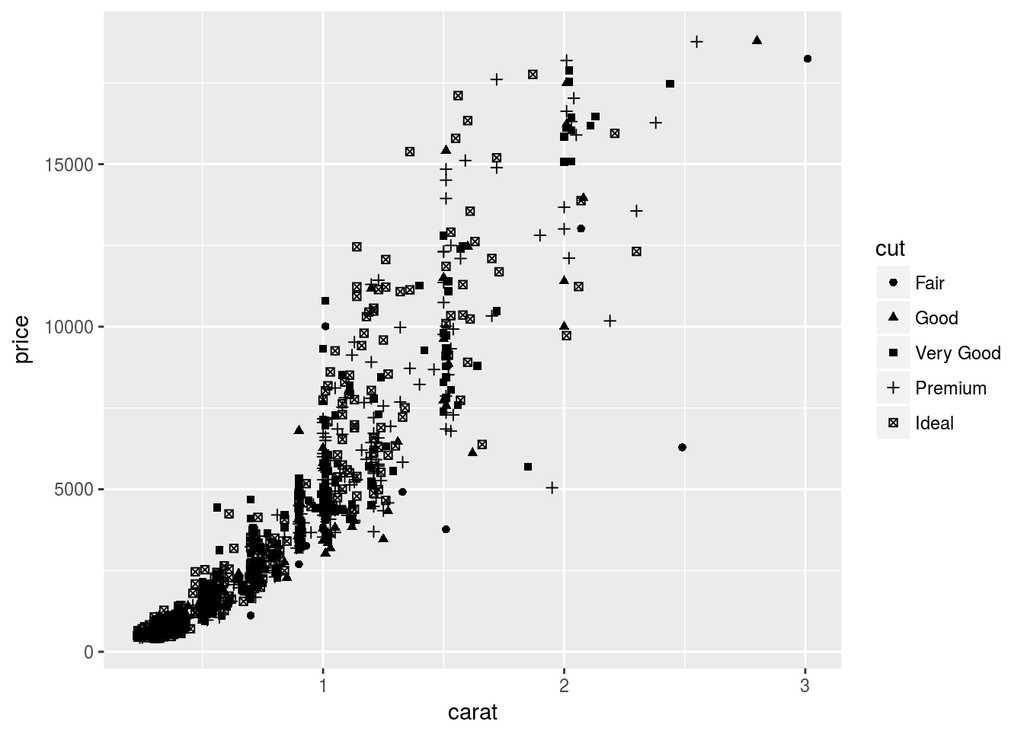

```r
ggplot(data = diamonds_sample) +
  geom_point(mapping = aes(x = carat, y = price, shape = cut))
```

Draw a scatter plot for `diamonds_sample` of *`cut`* by `carat`, where each point has an aesthetic *size* based on the diamond’s *`price`*

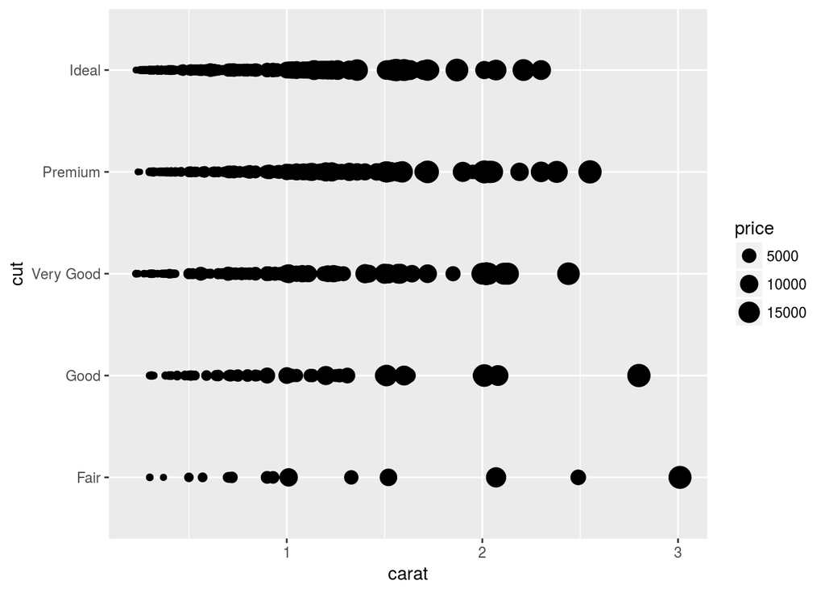

```r
ggplot(data = diamonds_sample) +
  geom_point(mapping = aes(x = carat, y = cut, size = price))
```

Try coloring the above plot based on the diamond’s price!

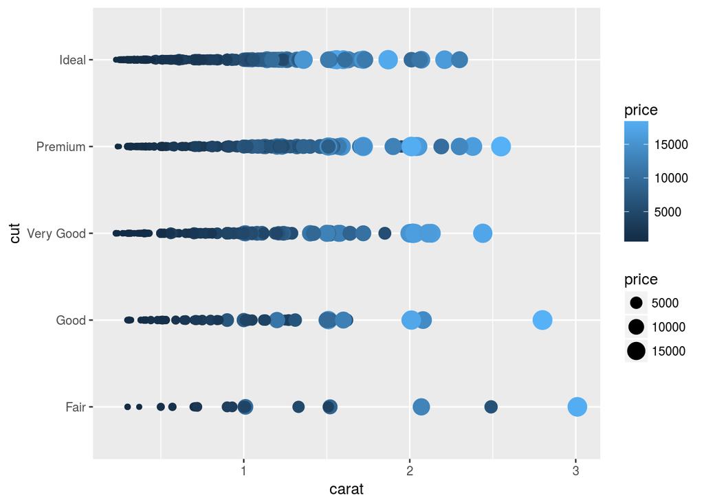

```r
ggplot(data = diamonds_sample) +
  geom_point(mapping = aes(x = carat, y = cut, size = price, color = price))
```

Draw a line plot (with line geometry) for `diamonds_sample`. The x-position should be mapped to carat, y-position to price, and color to cut.

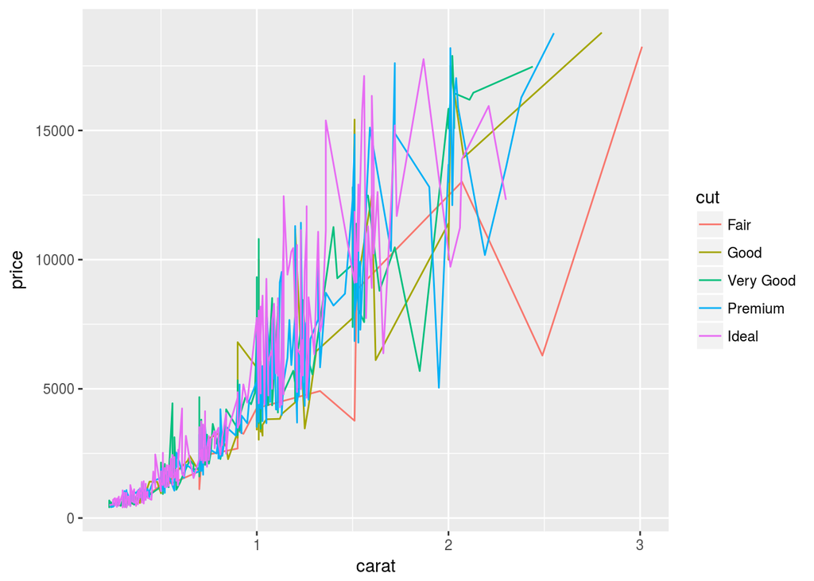

```r
ggplot(data = diamonds_sample) +
  geom_line(mapping = aes(x = carat, y = price, color = cut))
```

That’s kind of messy. Try using `smooth` geometry instead.

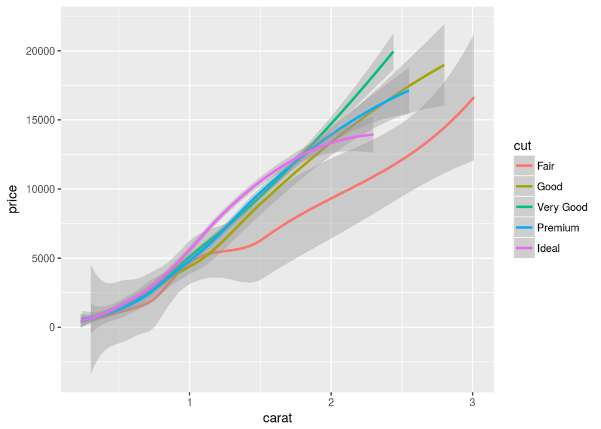

```r
ggplot(data = diamonds_sample) +
  geom_smooth(mapping = aes(x = carat, y = price, color = cut))
```

Draw a plot with bar geometry (a bar chart), mapping the diamond’s `cut` to the x-axis

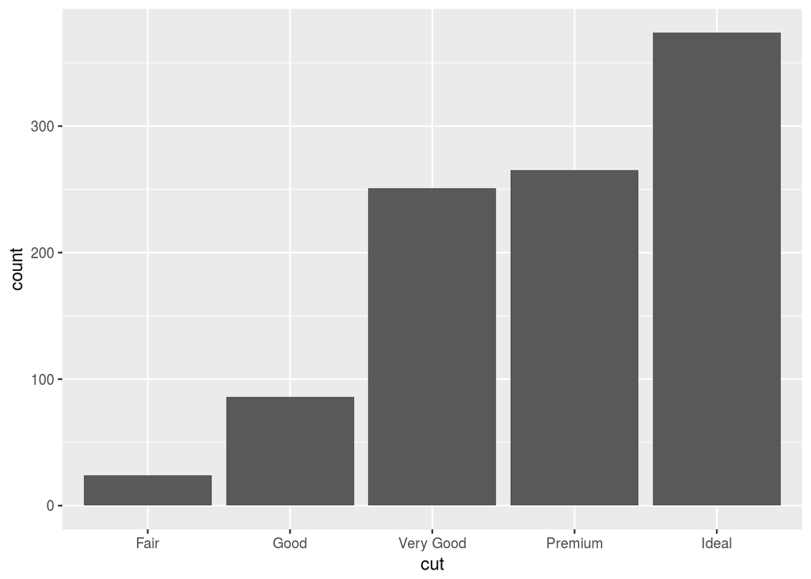

```r
ggplot(data = diamonds_sample) +
  geom_bar(mapping = aes(x = cut))
```

Add an aesthetic property that will *fill* each bar geometry based on the `clarity` of the diamonds. What kind of chart do you get?

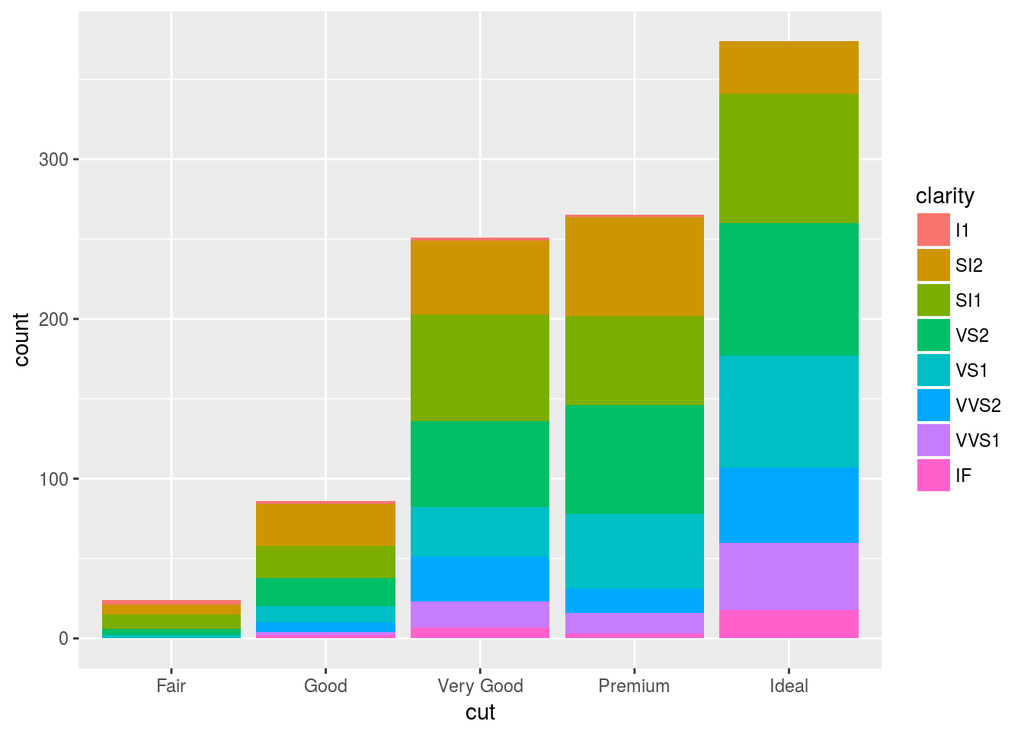

```r
ggplot(data = diamonds_sample) +
  geom_bar(mapping = aes(x = cut, fill = clarity))
```

Draw a histogram (using histogram geometry) of diamond prices. Try mapping each bar based on clarity as well!

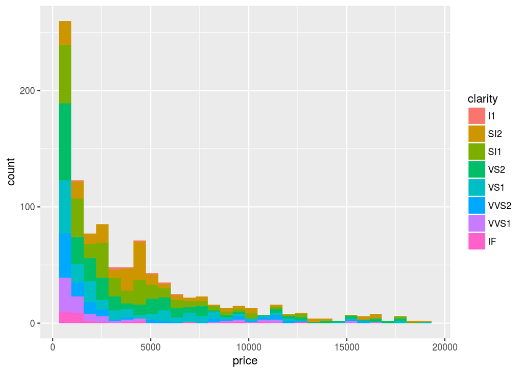

```r
ggplot(data = diamonds_sample) +
  geom_histogram(mapping = aes(x = price, fill = clarity))
```

(For a more traditional “bell-curve”, make a histogram of diamond `depth`)

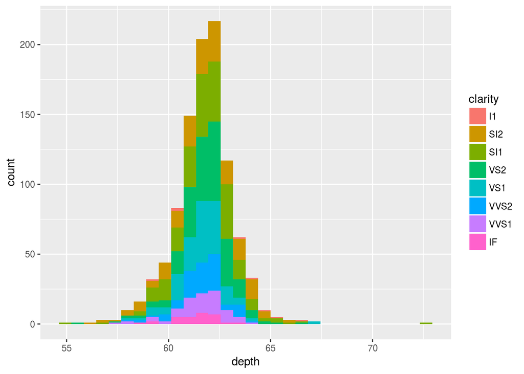

```r
ggplot(data = diamonds_sample) +
  geom_histogram(mapping = aes(x = depth, fill = clarity))
```

Draw a plot of the `diamonds_sample` data (price by carat), with both points for each diamond AND smoothed lines for each cut (hint: in a separate color) Give the points an `alpha` (transparency) of 0.3 to make the plot look nicer

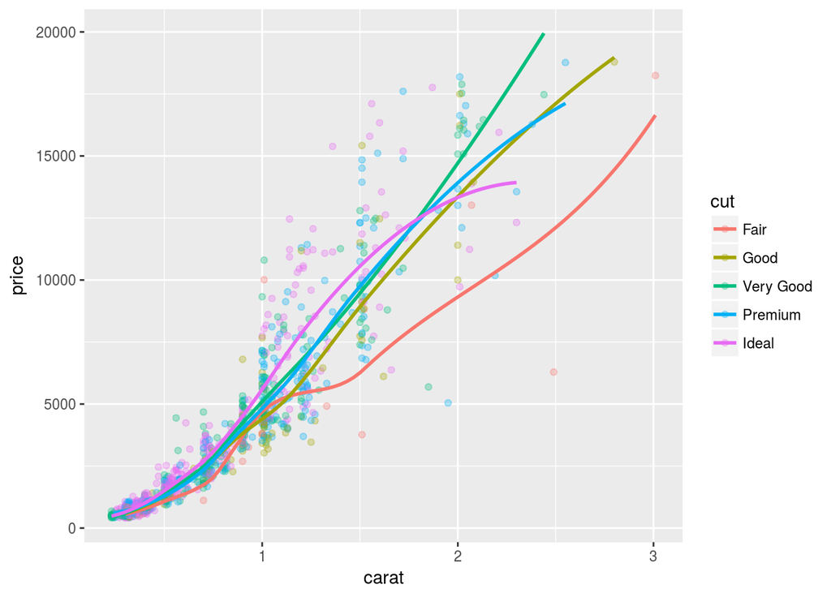

```r
ggplot(data = diamonds_sample) +
  geom_point(mapping = aes(x = carat, y = price, color = cut), alpha = 0.3) +
  geom_smooth(mapping = aes(x = carat, y = price, color = cut), se = FALSE)
```

# Bonus

Draw a bar chart of average diamond prices by clarity, and include “error bars” marking the standard error of each measurement.

You can calculate standard error as the *standard deviation* divided by the square root of the number of measurements (prices)

Start by creating a data frame `clarity_summary` that includes summarized data for each clarity group. Your summary data should include the mean price and the standard error of the price.

```r
clarity_summary <- diamonds %>%
  group_by(clarity) %>%
  summarize(mean = mean(price), sd = sd(price), se = sd/sqrt(length(price)))
```

Then draw the plot. The error bars should stretch from the mean-error to the mean+error.

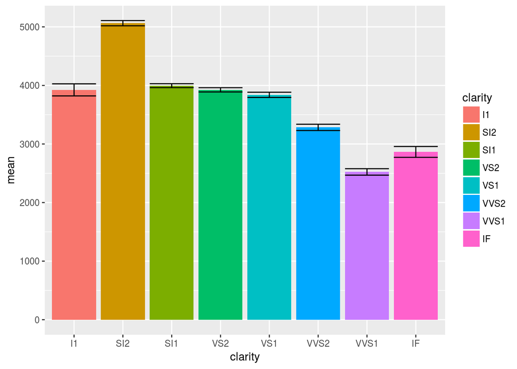

```r
ggplot(data = clarity_summary, mapping = aes(x = clarity, y = mean)) +
  geom_bar(mapping = aes(fill = clarity), stat = "identity") +
  geom_errorbar(mapping = aes(ymin = (mean-se), ymax = (mean+se)))
```